# Laboratorio 1 en R: Introducción

Kerry Loaiza Marín

[figure not shown]

En este laboratorio se utilizarán los siguientes archivos:

Download table3-1.dat Download ejemplo3.xlsx Download Tipos_de_cambio.xlsx Download LONDON.dat

# 1 Importación de datos

Siempre es importante conocer la estructura de los datos (serie de tiempo, corte transversal o datos de panel), su frecuencia, cantidad de observaciones, si posee encabezados (nombre de variables o columnas), si son datos limpios o requieren de procesamiento para su uso, entre otros. Ello es necesario para darle tratamiento a los datos y realizar transformaciones.

**Ejemplo 1:** Acá, se importarán los datos del archivo “table3-1.dat”. Estos se componen de 2 series de 40 observaciones sin estructura temporal. **Recuerde** definir previamente el directorio de trabajo (setwd).

```r
datos <-  read.table("table3-1.dat", header = TRUE)

#La extensión .dat es genérica, entonces no se pueden usar los comandos read.csv ni read_xlsx. Estos datos están separados por tabulaciones, por lo que no es necesario definir el separador en la función de importación read.table. Sin embargo, los datos sí poseen nombre de las columnas o variables, lo debe especificarse en la función.
```

**Ejemplo 2:** Ahora importe el archivo “Ejemplo3.xlsx” que contiene dos series de tiempo: IMAE e IPC (son datos de la página del BCCR y fueron previamente acomodados en columnas). Son datos mensuales que inician en enero de 1991 y terminan en diciembre de 2013.

```r
#Como es un archivo de excel, se debe utilizar el paquete "openxlsx" que contiene funciones para importar o exportar archivos .xlsx.

#Otra opción es el paquete "xlsx" que contiene funciones similares. Este depende de Java por lo que puede generar errores si existen problemas con Java, pero lee bien el formato de los datos en el excel (fechas).

#Una opción (la más utilizada antes de estas librerías), es trasladar (transformar) los datos (archivos) a .csv e importar con read.table o read.csv

#También se puede importar/exportar archivos SAS, SPSS, Stata en R con el paquete foreign. Eviews es más difícil de manejar, por lo que se recomienda pasar los datos a excel.

library(openxlsx)

#Se usa la función read.xlsx, debe indicarse el nombre de la hoja de excel a cargar o su posición dentro del excel!!
datos1 <- read.xlsx("ejemplo3.xlsx", colNames =  TRUE, sheet = "Hoja1")

str(datos1)#La función "str" resume los objetos o variables y sus clases que se encuentran dentro del objeto que llamamos
```

```
## 'data.frame':    276 obs. of  3 variables:
##  $ FECHA: num  33239 33270 33298 33329 33359 ...
##  $ IMAE : num  102.9 101.9 97.8 96.6 100 ...
##  $ IPC  : num  13.8 14.2 14.4 14.8 15 ...
```

```r
#Es necesario cambiar la clase de la variable a fecha para su uso y reconocimiento correcto en R.

#Sin embargo, para modelación no es necesario tener una variable fecha específica. Cada varible en R puede cambiarse para que sea tipo fecha o tipo panel. Para corte transversal no es necesaria esta transformación.

#Cuando dos paquetes contienen funciones con el mismo nombre, hay conflicto al llamarlas (se sobreescribieron las funciones del primer paquete cargado con las funciones del segundo paquete cargado).
#Para evitar la confusión se puede indicar a R qué paquete y qué función se desea usar con: paquete::función
```

Veamos como asignar el formato de fecha a nuestra variable FECHA.

```r
#La función as.Date de la base de R (ya integrado sin necesidad de instalar paquetes adicionales) es la función más simple para transformar un texto con las fechas a las fechas de series de tiempo

#Versión openxlsx
Fecha1 <- as.Date(datos1$FECHA, origin = "1899-12-30")
class(Fecha1)
```

```
## [1] "Date"
```

```r
head(Fecha1)
```

```
## [1] "1991-01-01" "1991-02-01" "1991-03-01" "1991-04-01" "1991-05-01"
## [6] "1991-06-01"
```

```r
#Note que en el menú de ayuda de la función as.Date se indica lo siguiente:
## So for dates (post-1901) from Windows Excel
#as.Date(35981, origin = "1899-12-30") # 1998-07-05
## and Mac Excel
#as.Date(34519, origin = "1904-01-01") # 1998-07-05
## (these values come from http://support.microsoft.com/kb/214330)
```

En la siguiente tabla vemos como manejar cada uno de los posibles formatos:

| **Símbolo** | **Significado** | **Ejemplo** |
| --- | --- | --- |
| %d | Número del día del mes | 01-**31** |
| %a | Abreviatura del nombre del día | dom. |
| %A | Nombre del día | domingo |
| %W | Número de la semana del año | 02 |
| %m | Número del mes en el año | **01**-31 |
| %b | Abreviatura del nombre del mes | ene. |
| %B | Nombre del mes | enero |
| %y | Año en 2 dígitos | 19 |
| %Y | Año en 4 dígitos | 2019 |
| %H | Horas | **08**:32:07 |
| %M | Minutos | 08:**32**:07 |
| %S | Segundos | 08:32:**07** |

**Nota**: por defecto los nombres se esperan en inglés. Para cambiar a español deben usarse los siguientes comandos:

```r
#Para Mac
#Sys.setlocale(locale = "es_ES.UTF-8")

#Para Windows
Sys.setlocale("LC_TIME", "Spanish")
```

```
## [1] "Spanish_Spain.1252"
```

```r
#Se debe tener precaución porque algunas computadores tiene la abreviatura del nombre con "." al fin y otras no.
```

Podemos asignar ese formato de fecha directamente a una variable de interés.

```r
#Se utiliza el paquete lubridate para manejar fecha de forma más flexible en R

library(lubridate)
#Asignamos el formato de fecha a la variable IMAE dentro de datos1
datos1$IMAE <- ts(datos1$IMAE, frequency = 12, start = c(1991,1))

#Verificamos el cambio de formato
str(datos1)
```

```
## 'data.frame':    276 obs. of  3 variables:
##  $ FECHA: num  33239 33270 33298 33329 33359 ...
##  $ IMAE : Time-Series  from 1991 to 2014: 102.9 101.9 97.8 96.6 100 ...
##  $ IPC  : num  13.8 14.2 14.4 14.8 15 ...
```

**Ejemplo 3:** Ahora se importarán datos diarios del 01/01/2011 al 14/02/2014 para las series del tipo de cambio: TC promedio de Monex, TC referencia de compra y TC referencia de venta. Luego se hará un filtro para que incluya solo observaciones mayores a 0 (esto eliminará los datos de fin de semana o feriados).

```r
#Se cargan los datos

datos2 <- read.xlsx("Tipos_de_cambio.xlsx", colNames = TRUE, sheet = 1)

head(datos2)
```

| Fecha | TC_compra | TC_venta | TC_prom_monex |
| --- | --- | --- | --- |
| 1 enero 2011 | 507.85 | 518.09 | 0.00 |
| 2 enero 2011 | 507.85 | 518.09 | 0.00 |
| 3 enero 2011 | 507.85 | 518.09 | 511.04 |
| 4 enero 2011 | 506.64 | 516.94 | 510.77 |
| 5 enero 2011 | 506.07 | 516.29 | 510.66 |
| 6 enero 2011 | 506.03 | 516.43 | 509.96 |

```r
datos3 <- datos2[datos2$TC_compra>0 & datos2$TC_venta >0 & datos2$TC_prom_monex>0,]
#En datos3 existe un problema porque TC_prom_monex tiene datos faltantes en algunas entradas (NA) en lugar de 0!!

#Eliminamos datos faltantes de la siguiente forma
datos4 <- na.omit(datos3)
```

# 2 Visualización de datos

Un primer paso en el análisis de datos es graficarlos para verificar que su formato sea el correcto y conocer caractarísticas de la variable. La función más simple en R para gráficar es plot(). También existen múltiples paquetes para realizar todo tipo de gráficos estáticos y dinámicos. ggplot2 es el paquete más utilizado para gráficos.

**Ejemplo 4:** Utilice un gráfico lineal para observar las 3 series de tipo de cambio anteriores.

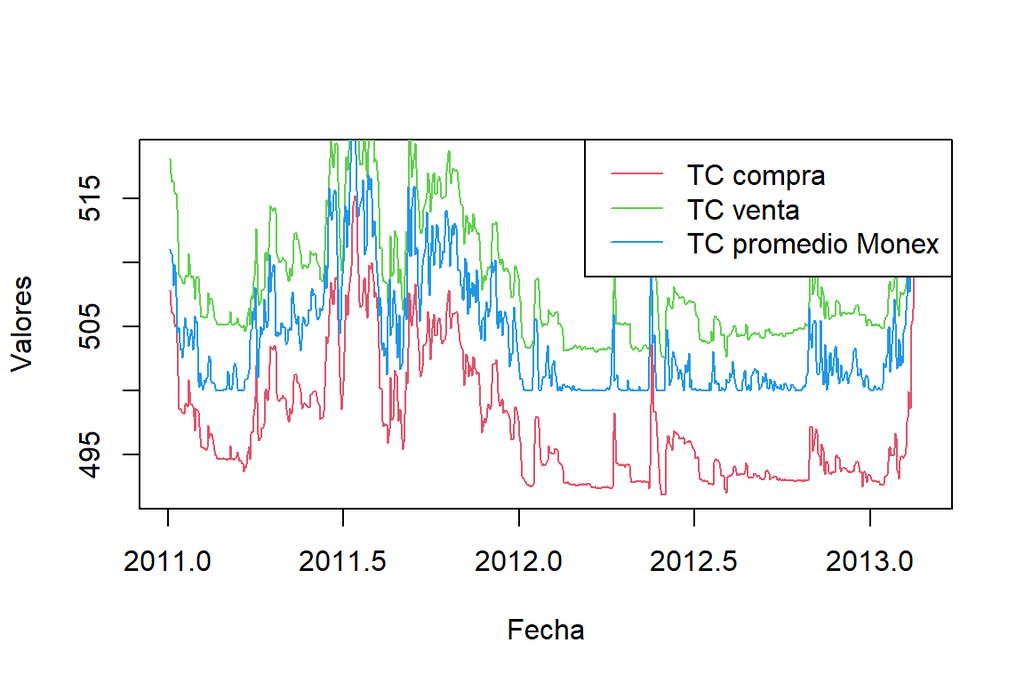

```r
#Se debe cambiar el formato de cada variable a serie de tiempo para su uso en el gráfico

datos4$TC_compra <- ts(datos4$TC_compra, frequency = 365,  start = c(2011,3))

datos4$TC_venta <- ts(datos4$TC_venta, frequency = 365,  start = c(2011,3))

datos4$TC_prom_monex <- ts(datos4$TC_prom_monex, frequency = 365,  start = c(2011,3))

plot(# Grafica la primera serie
     datos4$TC_compra,
     type = "l",
     col = 2,
     xlab = "Fecha",
     ylab = "Valores")
lines(# Grafica la segunda serie
      datos4$TC_venta,
      type = "l",
      col = 3)
lines(# Grafica la tercera serie
      datos4$TC_prom_monex,
      type = "l",
      col = 4)
legend("topright",      # Añade la leyenda al gráfico
       c("TC compra", "TC venta", "TC promedio Monex"),
       lty = 1,
       col = 2:4)
```

Con ggplot se pueden hacer gráficos más complejos, más personalizados y con mayor detalle. Sin embargo, es un poco engorroso para series de tiempo por que requiere los datos en formato “long”, es decir, todas las variables de interés en una misma columna y otra variable que defina las categorías (cuáles observaciones corresponde a cada variable).

```r
#Primero se deben transformar los datos a formato long

#Se cargan las librarías tidyr y dplyr, útiles para manejo de datos
library(dplyr)
library(tidyr)

#Se usa la función pivot_longer para cambiar los datos a formato long (el simbolo %>% es un pipe o un operador para realizar varias operaciones seguidas sobre el objeto, reescribiendo en cada operación)

datos5 <- datos4 %>% pivot_longer(
  cols = -Fecha, #Toma todas menos Fecha
  names_to = "Tipo_TC", #Define el nombre nuevo de la columna que guardará las categorías, i.e. los nombres viejos
  values_to = "Valores_TC" #Nombre de la columna que incluirá los valores
)

#Se cambia el formato de la variable Fecha
Sys.setlocale("LC_TIME", "Spanish")
```

```
## [1] "Spanish_Spain.1252"
```

```r
datos5$Fecha <- as.Date(datos5$Fecha, format = "%d %b %Y")

#Se muestra la nueva forma de los datos
head(datos5)
```

| Fecha | Tipo_TC | Valores_TC |
| --- | --- | --- |
| 2011-01-03 | TC_compra | 507.85 |
| 2011-01-03 | TC_venta | 518.09 |
| 2011-01-03 | TC_prom_monex | 511.04 |
| 2011-01-04 | TC_compra | 506.64 |
| 2011-01-04 | TC_venta | 516.94 |
| 2011-01-04 | TC_prom_monex | 510.77 |

[figure not shown]

```r
####################
#Se carga la librería ggplot
library(ggplot2)

# Se grafican las series de tiempo
graph_1 <- ggplot( data=datos5, mapping=aes(x=Fecha, y=Valores_TC, color=as.factor(Tipo_TC)) ) + #genera el espacio donde se graficará y los datos a utilizar, color es para graficar más de una serie y se separan por un factor que identifica las categorías
  geom_line( size=1 ) + #tipo de gráfico lineal
  scale_color_manual( values=c('#D55E00', '#009E73', '#000000'), name='Tipo de cambio', labels=c('Compra', 'Venta', 'Promedio Monex') ) +#Se da formato al gráfico de forma manual, se definen los colores con el código respectivo y el nombre de las variables
  scale_x_date(date_breaks = "3 month", #se presenta en el eje el valor de la fecha cada tres meses
           limits = as.Date(c('2011', 'mar 2014'), format="%Y"), #Se delimita el eje X de la fecha
           date_labels="%b %Y" ) + #Se da formato a la fecha a presenta "mes corto, espacio y año 4 dígitos"
  scale_y_continuous(labels = scales::comma)+#Se define el formato del eje Y
  # breaks=seq(0, 100, by=20), limits=c(0, 100) ) + este formato puede ser útil para definir los quiebres y límites de los ejes
  xlab( label='Fecha' ) +
  ylab( label='Colones por dólar' ) + #Se indican los nombres de los ejes
#  labs( caption='Nota: XXX', #Puede incluirse un título, nota y subtítulo en el gráfico
#        title = "XX",
#        subtitle = "XX\nXX.") +
  theme( legend.position='bottom', #elige la posición de la leyenda, colores de letra, su tamaño y otros aspectos del gráfico (color de fondo, etc)
         legend.text=element_text(size=10, color='black'),
         legend.title=element_text(size=10, color='black'),
         axis.text=element_text(size=10, color='black'),
         axis.text.x=element_text(angle=45, vjust = 1, hjust = 1),
         axis.title=element_text(size=10, color='black'),
         plot.caption=element_text(size=10, face='italic', hjust=0),
         panel.background=element_rect(fill='white'),
         panel.grid=element_line(color='gray80'),
         panel.border=element_rect(color='black', fill=NA),
         strip.background=element_rect(color='black', fill='black'),
         strip.text=element_text(size=10, color='white') )+guides(color=guide_legend(nrow=1,byrow=TRUE));
# Los gráficos de ggplot pueden guardarse con la función ggsave (guarda el último gráfico realizado!!). Hay que especificar la dirección, nombre del archivo y su extensión (.pdf). Útiles para pegarlos en word o latex.

ggsave( filename='C:/Users/kerry/Desktop/kerry/Cursos_UCR_profe/Econometria_basica/Laboratorios_econometria_basica_UCR/Lab 1/graph_tc.pdf' )
graph_1
```

Tipos de gráficos útiles en ggplot2:

1. geom_point() = puntos
2. geom_text() = text
3. geom_line() = líneas
4. geom_bar() = barras
5. geom_histogram() = histograma
6. geom_boxplot() = cajas y bigotes
7. geom_density() = curva de densidad

**Ejemplo 4:** Elabore un histograma que ilustre la distribución de la serie de tiempo denominada “TC promedio de Monex” de los ejercicios anteriores.

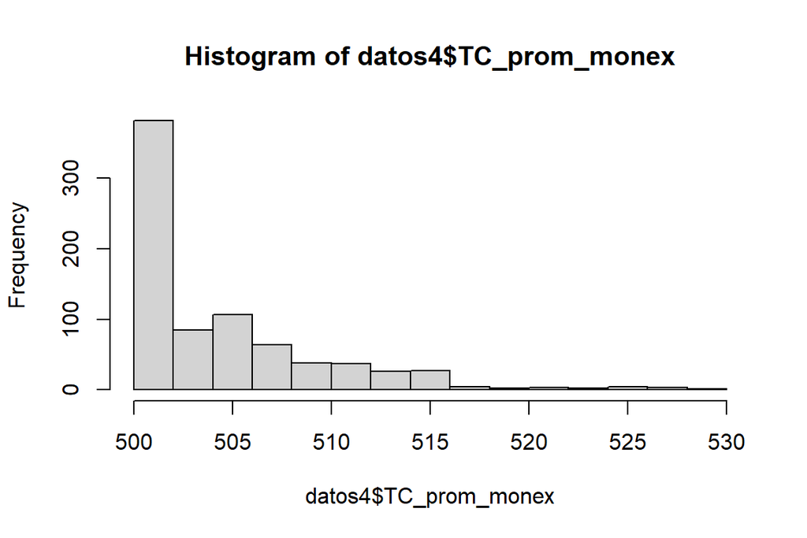

```r
#La función hist gráfica el histograma del objeto

hist(datos4$TC_prom_monex)
```

# 3 Estadísticos descriptivos

Existen múltiples funciones en R que facilitan el cálculo de estadísticos descriptivos. La función “summary” computa el promedio, mediana y algunos percentiles de los datos.

**Ejemplo 5:** Cree una serie de datos adicional que corresponda al promedio entre el TC de referencia de compra y el TC de referencia de venta. Luego compute diversos estadísticos descriptivos sobre esta.

```r
datos4$TC_prom_comp_vent <- (datos4$TC_compra+datos4$TC_venta)/2

promedio <- mean(datos4$TC_prom_comp_vent)
mediana <- median(datos4$TC_prom_comp_vent)
percentil_75 <- quantile(datos4$TC_prom_comp_vent, probs = c(0.75))

descriptivos <- summary(datos4$TC_prom_comp_vent)
```

Podemos darle un mejor formato a la tabla de descriptivos con la función **kable** del paquete **knitr** (usado para generar documentos y presentaciones desde R).

```r
#Nombres de las variables
nombres<-c("TC_compra", "TC_venta", "TC_prom_Monex", "TC_prom_comp_vent")

#Estadísticos descriptivos
attach(datos4)

estadisticas<-as.data.frame(matrix(data=NA, nrow = 4, ncol = 7))

for (i in 1:(length(datos4)-1)) {
  estadisticas[i,1]<-min(na.omit(datos4[,i+1]))
  estadisticas[i,2]<-quantile(na.omit(datos4[,i+1]), probs = 0.25)
  estadisticas[i,3]<-quantile(na.omit(datos4[,i+1]), probs = 0.5)
  estadisticas[i,4]<-mean(na.omit(datos4[,i+1]))
  estadisticas[i,5]<-quantile(na.omit(datos4[,i+1]), probs = 0.75)
  estadisticas[i,6]<-max(na.omit(datos4[,i+1]))
  estadisticas[i,7]<-sum(is.na(datos4[,i+1]))
}

colnames(estadisticas)<-c("Mínimo","Percentil 25", "Mediana", "Promedio", "Percentil 75", "Máximo", "Cantidad de NA's")

row.names(estadisticas)<-nombres

knitr::kable(estadisticas , caption = "Tabla de estadísticas descriptivas de variables"
       , align = c('c', 'c', 'c', 'c', 'c', 'c', 'c', 'c')
       , col.names = c("Mínimo","Percentil 25", "Mediana", "Promedio", "Percentil 75", "Máximo", "Cantidad de NA's")
       , row.names = T
       , digits = 2
      , format.args = list( decimal.mark = ".")
      )
```

Tabla de estadísticas descriptivas de variables

|  | Mínimo | Percentil 25 | Mediana | Promedio | Percentil 75 | Máximo | Cantidad de NA’s |
| --- | --- | --- | --- | --- | --- | --- | --- |
| TC_compra | 491.84 | 493.39 | 495.60 | 497.47 | 499.82 | 518.51 | 0 |
| TC_venta | 502.59 | 504.89 | 506.97 | 508.63 | 510.74 | 533.25 | 0 |
| TC_prom_Monex | 500.00 | 500.25 | 502.16 | 504.27 | 506.36 | 528.93 | 0 |
| TC_prom_comp_vent | 497.22 | 499.05 | 501.35 | 503.05 | 505.28 | 525.88 | 0 |

```r
#Nota: cuando se carga varios paquetes pueden existir conflictos si hay funciones con el mismo nombre. "::" evita este problema al llamar la función e indicarle a R cuál paquete debe utilizar.

#Se la tabla con los estadísticos se guarda en un archivo de excel

write.xlsx(estadisticas, file = "Estadisticas.xlsx", sheetName = "Estadisticas", col.names = TRUE, row.names = TRUE, overwrite = TRUE)
```

**Tarea 2:** El archivo london.dat es un corte transversal de 1419 hogares obtenidos de la Encuesta Británica de Gastos Familiares de los años 1981 y 1982. Los datos se seleccionaron incluyendo solo familias con 1 o 2 hijos que habitaban en el área conocida como “Great London”. Hogares dependientes de empleados por cuenta propia o de retirados fueron excluidos de la muestra. La descripción de las variables incluidas es la siguiente:

• wfood = porción (%) del presupuesto dedicada a gastos de alimentación

• wfuel = porción (%) del presupuesto dedicada a gastos en combustible

• wcloth = porción (%) del presupuesto dedicada a gastos en vestido

• walc = porción (%) del presupuesto dedicada a gastos en alcohol

• wtrans = porción (%) del presupuesto dedicada a gastos en trasnporte

• wother = porción (%) del presupuesto dedicada a otros gastos

• totexp = gasto total del hogar (redondeado al múltiplo más cercano de £10.000

• income = ingreso neto total del hogar

• age = edad de la cabeza de hogar

• nk = número de hijos

Realice lo siguiente:

1. Importe los datos en un objeto de nombre “tarea2” que pueda contener la estructura de datos del archivo “London.dat”.
2. Elabore un histograma de la variable wfood y guárdelo como objeto gráfico con nombre wfood_hist.
3. Elabore un cuadro con los estadísticos descriptivos más importantes de la variable wfood, guárdelo como un objeto.
4. Guarde el gráfico del ítem ii en un documento de PDF.
5. Cree una nueva variable llamada “gastos_b” que sea igual a la suma de wfood, wfuel, wcloth, walc, y wtrans.
6. Cree un vector de coeficientes que contenga el promedio, la variancia, el dato mayor y el menor de la serie “gastos_b” y llámele “resumen” y guardelo en un excel.
7. Guarde el todo el “Global Enrivonment” de R (donde están todos los objetos y resultados) con el nombre “Tarea_1_resuelta”. Recuerde usar la función **save.image**.